# 形の離散表現のパズルを考える

ryamada

2017年10月19日

# 1 イントロダクション

## 1.1 S2同相多様体

細胞の形のように、閉じた曲面であって、ドーナツの穴のようなものがない形を考える。

滑らかな変形によって、真ん丸なボールに変形できるので、真ん丸なボール(S2と呼ぶ)とトポロジー(位相)の観点で等しいことから、S2同相な多様体と呼ぶ。

以下の話はS2同相多様体にメッシュを入れて、離散的に取り扱う話である。

## 1.2 グラフと平面グラフ

S2同相多様体Mにメッシュを入れる。

メッシュの交叉点を「ノード」とし、「ノード」と「ノード」をつなぐ線分を「エッジ」と呼ぶことにする。

M上のメッシュは、ノードの集合と、エッジの集合として定められる。

ノードの集合とエッジの集合の組のことを「グラフ」と呼ぶ。

したがって、M上のグラフを考えることができる。

M上のメッシュに対応するグラフGは多角形の敷き詰めと見ることもできる。

今、M上のメッシュに対応する多角形敷き詰めグラフの、一つの多角形を選び、それをぐいっと大きくしてどんどん広げていくと、それ以外の多角形はすべて、広げた一つの多角形の内側に来る。

そのようにして、二次元平面にすべての点を置くと、外周が選らんだ多角形とできる。

また、すべてのエッジはうまく引けば、互いに交叉することなく引ける。

このように、平面上にエッジの交叉がないように描けるグラフを平面グラフと呼ぶ。

M上メッシュグラフは平面グラフである。

### 1.2.1 Rでグラフ

Rのグラフパッケージ igraphとRBGLとを使う。

igraphパッケージはCRANから、RBGLはBioconductorから入手する。

８面体グラフを作成する。

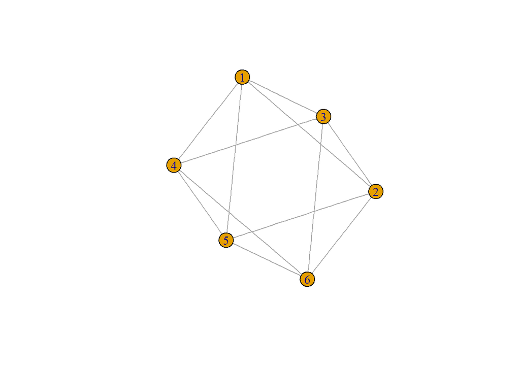

```r
edge.list <- matrix(c(1,2,1,3,1,4,1,5,2,3,3,4,4,5,5,2,2,6,3,6,4,6,5,6),byrow=TRUE,ncol=2)
g <- graph.edgelist(edge.list,directed=FALSE)
plot(g)
```

平面グラフであることを確認する。

```r
g.rbgl <- as_graphnel(g)
g.conn <- makeBiconnectedPlanar(g.rbgl)
g.conn
```

```
## $`Is planar: `
## [1] TRUE
##
## $`new graph`
## A graphNEL graph with undirected edges
## Number of Nodes = 6
## Number of Edges = 12
```

## 1.3 グラフの隣接行列

グラフはノードの集合とエッジの集合の組であった。

このノードの集合とエッジの集合は、ノード数ｘノード数の行列で表現できることが知られている。

ノードのペアの間にエッジが存在するときに、ノードペアに対応するセルの値を１とし、そうでないときに０としたものがグラフの隣接行列と呼ぶ。

```r
adj.mat <- as_adj(g)
adj.mat
```

```
## 6 x 6 sparse Matrix of class "dgCMatrix"
##
## [1,] . 1 1 1 1 .
## [2,] 1 . 1 . 1 1
## [3,] 1 1 . 1 . 1
## [4,] 1 . 1 . 1 1
## [5,] 1 1 . 1 . 1
## [6,] . 1 1 1 1 .
```

## 1.4 ノード間の最短距離

```r
distances(g)
```

```
##      [,1] [,2] [,3] [,4] [,5] [,6]
## [1,]    0    1    1    1    1    2
## [2,]    1    0    1    2    1    1
## [3,]    1    1    0    1    2    1
## [4,]    1    2    1    0    1    1
## [5,]    1    1    2    1    0    1
## [6,]    2    1    1    1    1    0
```

この最短距離は、すべてのエッジの長さを１として計算したが、エッジに長さを持たせることが出来る。 その上でノード間最短距離を算出してみる。

```r
n.edge <- length(edge.list[,1])
edge.len <- runif(n.edge)
round(distances(g,weight=edge.len),3)
```

```
##       [,1]  [,2]  [,3]  [,4]  [,5]  [,6]
## [1,] 0.000 0.239 0.459 0.538 0.277 0.440
## [2,] 0.239 0.000 0.221 0.776 0.515 0.453
## [3,] 0.459 0.221 0.000 0.678 0.395 0.233
## [4,] 0.538 0.776 0.678 0.000 0.391 0.554
## [5,] 0.277 0.515 0.395 0.391 0.000 0.163
## [6,] 0.440 0.453 0.233 0.554 0.163 0.000
```

## 1.5 最短距離のパス(測地線)

最短距離にはそれを実現する経路がある。

あるノードから、すべてのノードへの最短経路を確認する。

この最短経路をグラフ上の測地線と呼ぶ。

```r
all_shortest_paths(g,1) # 第１ノードからの最短経路
```

```
## $res
## $res[[1]]
## + 1/6 vertex:
## [1] 1
##
## $res[[2]]
## + 2/6 vertices:
## [1] 1 2
##
## $res[[3]]
## + 2/6 vertices:
## [1] 1 3
##
## $res[[4]]
## + 2/6 vertices:
## [1] 1 4
##
## $res[[5]]
## + 2/6 vertices:
## [1] 1 5
##
## $res[[6]]
## + 3/6 vertices:
## [1] 1 5 6
##
## $res[[7]]
## + 3/6 vertices:
## [1] 1 4 6
##
## $res[[8]]
## + 3/6 vertices:
## [1] 1 3 6
##
## $res[[9]]
## + 3/6 vertices:
## [1] 1 2 6
##
##
## $nrgeo
## [1] 1 1 1 1 1 4
```

グラフには、すべてのノードペアの最短距離行列が付随しているとともに、すべてのノードペアの間の最短経路情報も付随していることを意味している。

## 1.6 順序

あるノードからの最短距離の大小を比較すると、すべてのノードに順序が付与できる。

## 1.7 測地線上のノードの順序

今、２つのノード $V_i,v_j$を取ると、その測地線は、ノードの列として表せる。

それを
$$P(v_i \rightarrow v_j) = (v_{s_1}^{ij},v_{s_2}^{ij},...,v_{s_{n^{ij}}}^{ij})$$
と書くことにする。 ただし、$S^{ij} = (s_1,...,s_{n^{ij}})$は、ノードの添え字の列であり、$s_1=i,s_{n^{ij}}=j$

```r
geodesicsFun <- function(name="", vertexNum)
{
  object <- readOBJ(name)
  vertex.xyz <- t(object[[1]][1:3,])
  edges <- unique(rbind(t(object[[2]][1:2,]),t(object[[2]][2:3,]),t(object[[2]][c(3,1),])))
  edgesLen <- sqrt(apply((vertex.xyz[edges[,1],] - vertex.xyz[edges[,2],])^2,1,sum))
  distance <- distances(graph.edgelist(edges), weights=edgesLen)
  normalizeDistance <- distance/max(distance)

  geodesicsColor <- ceiling(normalizeDistance[vertexNum,] * 15)+1

  output <- list(vertex.xyz, normalizeDistance, geodesicsColor)
  return (output)
}

vertexNum <- 30

#bunny geodesics
bunnyRet = geodesicsFun("bunnytest.obj", vertexNum)

open3d()
```

```
## wgl
##   1
```

```r
plot3d(bunnyRet[[1]][, 1], bunnyRet[[1]][, 2], bunnyRet[[1]][, 3], xlab = "bunny geodesics")
spheres3d(bunnyRet[[1]][, 1], bunnyRet[[1]][, 2], bunnyRet[[1]][, 3],radius=0.03,col=bunnyRet[[3]])

#sphere geodesics
sphereRet = geodesicsFun("spheretest.obj", vertexNum)

open3d()
```

```
## wgl
##   2
```

```r
plot3d(sphereRet[[1]][, 1], sphereRet[[1]][, 2], sphereRet[[1]][, 3], xlab = "sphere geodesics")
spheres3d(sphereRet[[1]][, 1], sphereRet[[1]][, 2], sphereRet[[1]][, 3],radius=0.03,col=sphereRet[[3]])

#difference
differentGeodesics <- (bunnyRet[[2]] - sphereRet[[2]])
differentGeodesics <- differentGeodesics + max(differentGeodesics)
differentGeodesicsColor <- ceiling(differentGeodesics[vertexNum,] * 15)+1

open3d()
```

```
## wgl
##   3
```

```r
plot3d(bunnyRet[[1]][, 1], bunnyRet[[1]][, 2], bunnyRet[[1]][, 3], xlab = "bunny geodesics sphere geodesics difference")
spheres3d(bunnyRet[[1]][, 1], bunnyRet[[1]][, 2], bunnyRet[[1]][, 3],radius=0.03,col=differentGeodesicsColor)

#bunny vertex, sphere geodesics
open3d()
```

```
## wgl
##   4
```

```r
plot3d(bunnyRet[[1]][, 1], bunnyRet[[1]][, 2], bunnyRet[[1]][, 3], xlab = "bunny vertex, sphere geodesics")
spheres3d(bunnyRet[[1]][, 1], bunnyRet[[1]][, 2], bunnyRet[[1]][, 3],radius=0.03,col=sphereRet[[3]])

#sphere vertex, bunny geodesics
open3d()
```

```
## wgl
##   5
```

```r
plot3d(sphereRet[[1]][, 1], sphereRet[[1]][, 2], sphereRet[[1]][, 3], xlab = "sphere vertex, bunny geodesics")
spheres3d(sphereRet[[1]][, 1], sphereRet[[1]][, 2], sphereRet[[1]][, 3],radius=0.03,col=bunnyRet[[3]])
```